# Analysis of Mass Shootings Across the U.S.

Salma Emjaheed

11/1/2022

## Section 1. Introduction

This data set came from Mother Jones researchers on four decades of mass shooting cases, from 1982 to 2022, including information on the attackers’ profiles, the types of weapons they used, and the number of victims they injured and killed. Each row represents a mass shooting event. The values in the sources variable in the data link to websites that have the news or more information about the mass shooting; this is how it was collected. For the purposes of this data set, a mass shooting is defined as a shooting that occurred in a public place or a place that was filled with a crowd, such as a private property where strangers (public crowd) were in it. Each case leading up to the year 2012 was of a mass shooting where at least four people died. And the cases from the years 2013 to 2022 are of mass shootings where at least three people died. For each case, only one shooter was involved, except in two cases where two shooters were involved. There are some spree killings as opposed to mass shootings, where the shootings happen in different locations but over a short period of time and by the same perpetrator. In many cases, the perpetrators were killed or wounded, either by themselves or someone else; in this data set, they are not counted under the variable total victims. The variables are case, location, date, summary, fatalities, injured, total victims, prior signs of mental health issues, mental health details, weapons obtained illegally, where the weapons were obtained, weapon type, weapon details, race, gender, latitude, longitude, type, and year. I want to take a look at how the demographics (age, race, and gender) of the perpetrators changed over the years, starting in 1982.

Research questions Are the perpetrators, before the 21st century, more likely to be majority male, majority white, and majority under 40? The purpose of this question is to see how the gender, race, and age demographics of perpetrators have changed over the years. What is the location_type that has had the most mass shootings occur in it? From the most common location, what age of perpetrator is most common? Are people who are in their late teens or 20s more likely to steal a weapon from a family member? Are the fatalities much higher when the weapon was stolen or obtained illegally than when it was not obtained illegally I can find this information from weapon details, but will need to make a new column out of it.

What are the 10 most commonly used weapons in a mass shooting? – I want to make a new data set for this, where each row represents a gun type. There will be two columns, one for count and one for weapon type. The count will be a more accurate count of each type of weapon that was used. The weapon_type count in this data set counts how many semiautomatic handguns there are and how many semiautomatic handguns and revolvers there are separately. For example, it shows there are three semiautomatic handguns and two semiautomatic handguns and revolvers. With the new data set, I want to show that there are five semiautomatic handguns and two revolvers. The purpose of this question is to see what types of guns mass shooters have access to the most. Which types are obtained the most, either legally or illegally? I could break it down further to see if the top five are obtained legally and the top five are obtained illegally. This might show me if some weapons are always obtained legally and if some weapons are always obtained illegally. I could also facet by weapon types and have box plots of the ages to see the distribution of shooter ages per weapon type (only the top 10).

Linear model question: Is there a correlation between shooter age and fatalities? Is there a correlation between shooter age and year?

```
## Rows: 133
## Columns: 24
## $ case                             <chr> "Greenwood Park Mall shooting", "High…
## $ location...2                     <chr> "Greenwood, Indiana", "Highland Park,…
## $ date                             <dttm> 2022-07-17, 2022-07-04, 2022-06-16, …
## $ summary                          <chr> "Jonathan Sapirman, 20, opened fire i…
## $ fatalities                       <dbl> 3, 7, 3, 3, 4, 21, 10, 4, 4, 9, 8, 4,…
## $ injured                          <chr> "2", "46", "0", "1", "(TK - \"fewer t…
## $ total_victims                    <chr> "5", "53", "3", "4", "TK", "38", "13"…
## $ location...8                     <chr> "workplace", "Other", "religious", "w…
## $ age_of_shooter                   <dbl> 20, 21, 70, 23, NA, 18, 18, NA, 15, 5…
## $ prior_signs_mental_health_issues <chr> NA, NA, NA, NA, NA, "yes", "yes", NA,…
## $ mental_health_details            <chr> NA, NA, NA, NA, NA, NA, "previous thr…
## $ weapons_obtained_legally         <chr> "yes", "yes", "yes", NA, "yes", "yes"…
## $ where_obtained                   <chr> "in Greenwood", "legally purchased by…
## $ weapon_type                      <chr> "semiautomatic rifles; semiautomatic …
## $ weapon_details                   <chr> "Sig Sauer M400 rifle", "AR-15 style …
## $ race                             <chr> "White", "White", "White", NA, "Black…
## $ gender                           <chr> "M", "M", "M", "M", "M", "M", "M", "M…
## $ sources                          <chr> "https://apnews.com/article/indiana-m…
## $ mental_health_sources            <chr> NA, NA, NA, NA, NA, NA, "https://www.…
## $ sources_additional_age           <chr> NA, NA, NA, NA, NA, NA, NA, NA, NA, N…
## $ latitude                         <dbl> NA, NA, NA, NA, NA, NA, NA, 38.60111,…
## $ longitude                        <dbl> NA, NA, NA, NA, NA, NA, NA, -121.4189…
## $ type                             <chr> "Mass", "Mass", "Mass", "Mass", "Mass…
## $ year                             <dbl> 2022, 2022, 2022, 2022, 2022, 2022, 2…
```

Data source: https://www.motherjones.com/politics/2012/12/mass-shootings-mother-jones-full-data/

## Section 2. Data analysis plan

Explanatory Data Analysis description: First, I renamed location…8, and location…2 to location_type and location. This dataset had two columns named location, so r named added …8 and …2 at the end of both of them to differentiate them.

From the details column, I extracted the shooter’s name using the separate function. I noticed that most of the values in the details column started with shooter’s name followed by a comma, age, and details of the case. This is why I separated these values by comma and extracted shooter’s full name from details. Because not all of the values were structured that way, I had to use mutate and case_when to change some of the values in the shooter’s name. From there, I used string extract to take the last name of shooter from shooter’s name column and put in a shooter’s last name column. Then, I used word and passed in 1 to extract the first word in column shooter’s name, which I put in a new column called shooter’s first name. I moved both of these columns to be the fifth and sixth columns instead of at the very end of the data set. I removed shooter’s name because it was unnecessary. For the rows that had two shooters, I made sure to use case when and add both names to shooter’s first name and shooter’s last names because only one of the names was extracted.

I also separated the column location, which had city and state separated by a comma. I used the separate function for that too, creating two columns state and city. The gender column had five levels F, M, Female, Male and Female & Male. I cleaned that up with mutate and case_when, creating only three levels.

The location type column had two workplace levels, one with an upper case “W,” and with a lower case “w.” Same problem with the religious column. Also, with the column race, levels black and white had the same problem and I fixed it the same way by case_when.

For the weapon’s ilegally obtained I changed all the “yes” to “Yes,” ‘Yes (“some of the weapons were purchased legally and some of them may not have been”)’ to “Some,” and “Kelley passed federal criminal background checks; the US Air Force failed to provide information on his criminal history to the FBI” to “Unknown.” There were multiple new line characters within different levels, which I removed as well.

For the shooter age column, there were three NA. I was able to find their ages in the details columns, so I mutated them and changed thoes NA to the correct age of shooter.

I made a century column, which had two categories: 20th century and 21 century. Each category had about 20 years. I used this to compare the counts of cases per level.

Made a shooter’s names column and moved all summary column to the end.

Clean up values in the gender column

There are two rows where a female and a male were involved. I filled in one with “47 & 50”, which is information I took from the summary column. The other row, where two shooters were involved, however, is filled in with age 28. Does that mean both shooters were 28? Or is there a mistake?

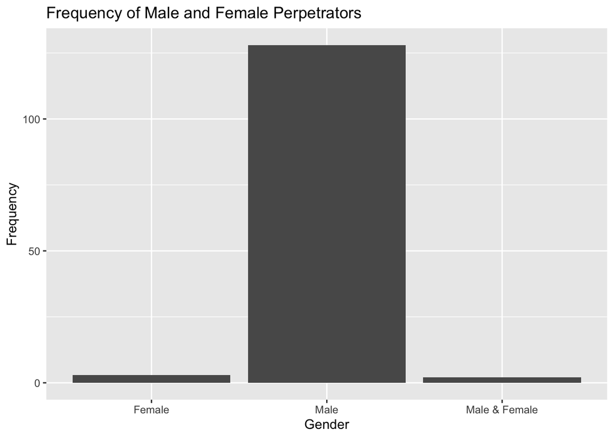

```
## # A tibble: 3 × 2
##   gender            n
##   <chr>         <int>
## 1 Female            3
## 2 Male            128
## 3 Male & Female     2
```

It is obvious here that the male frequency is much higher in this data set. This shows me that males are more likely to be perpetrators in a mass shooting. From this graph, I know that I should not compare females and males in any of my analyses, as it will not be efficient since there are only three females.

```
## # A tibble: 2 × 2
##   by_century       n
##   <chr>        <int>
## 1 20th Century    31
## 2 21st Century   102
```

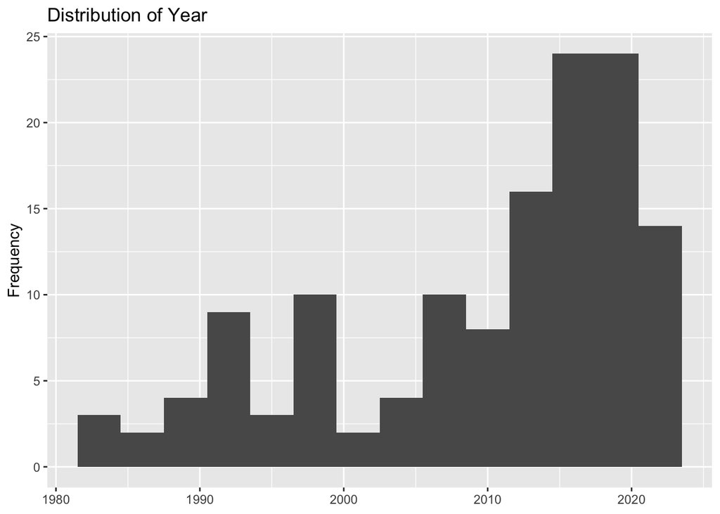

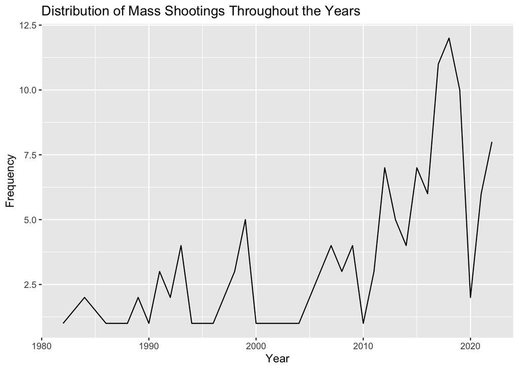

The second chart shows more clearly the increase throughout the years. Before the year 2000, the slope of the number of mass shootings looked much lower than after the year 2000. After the year 2000, the number of mass shootings increased much faster (the slope looks higher than before 2000).

```
## # A tibble: 1 × 5
##    Mean Maximum Minimum Median    SD
##   <dbl>   <dbl>   <dbl>  <dbl> <dbl>
## 1  33.9      70      11   33.5  12.6
```

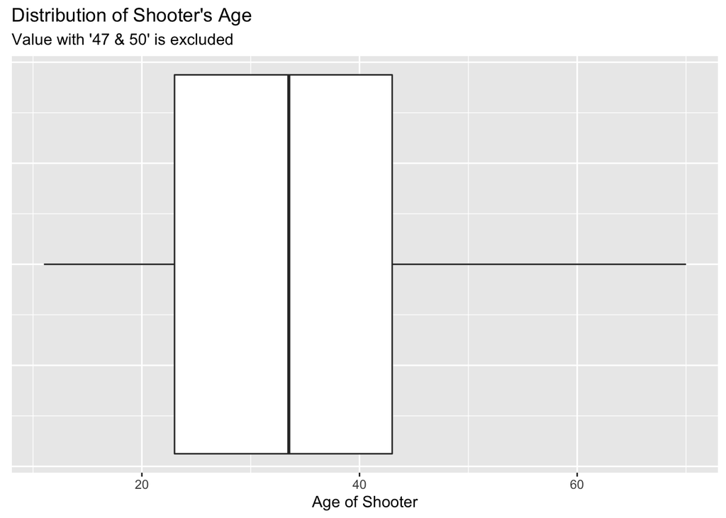

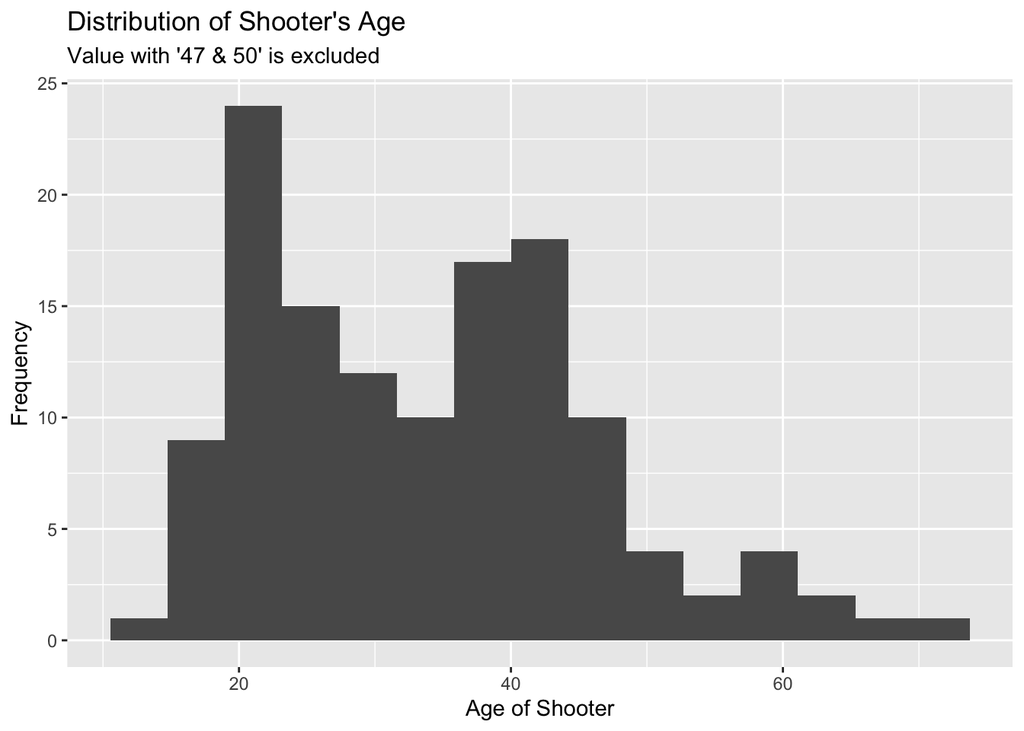

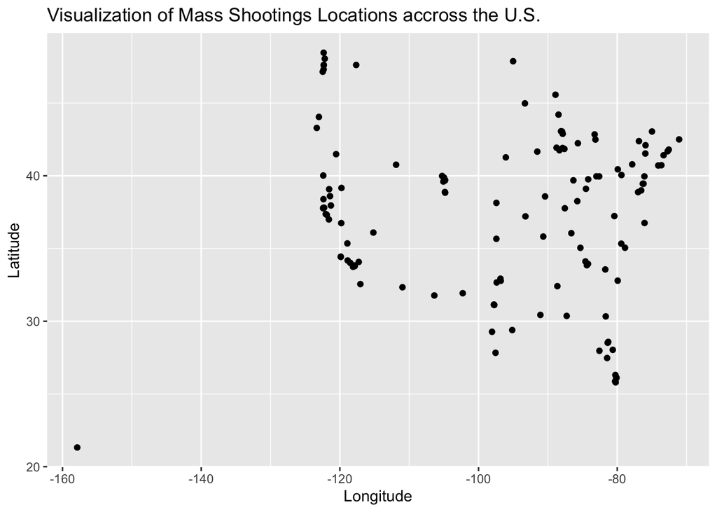

More shootings happen around the major states, especially the states that are on the border or the coast. This makes sense because most of the major states are towards the border. These states are more populated than the ones in the middle.

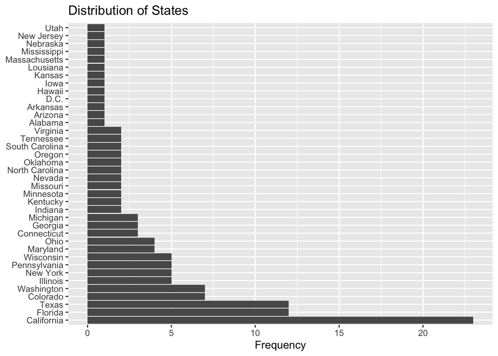

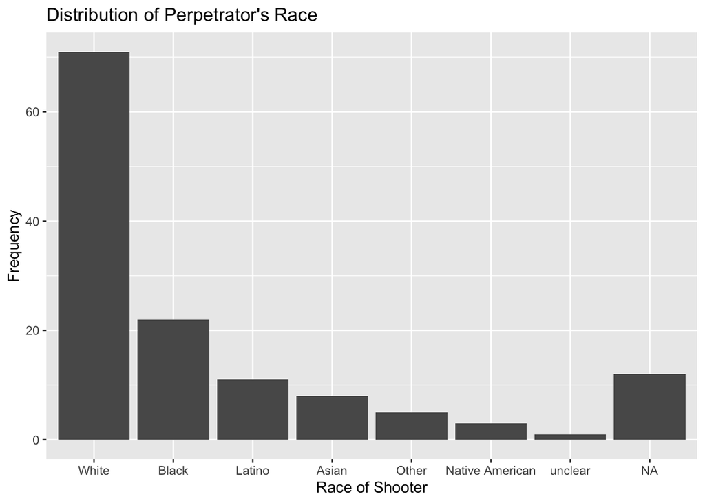

The highest number of perpetrators were white, and the lowest number were Native Americans. This makes sense because the majority of people are white, and Native Americans are one of the minorities in this country.

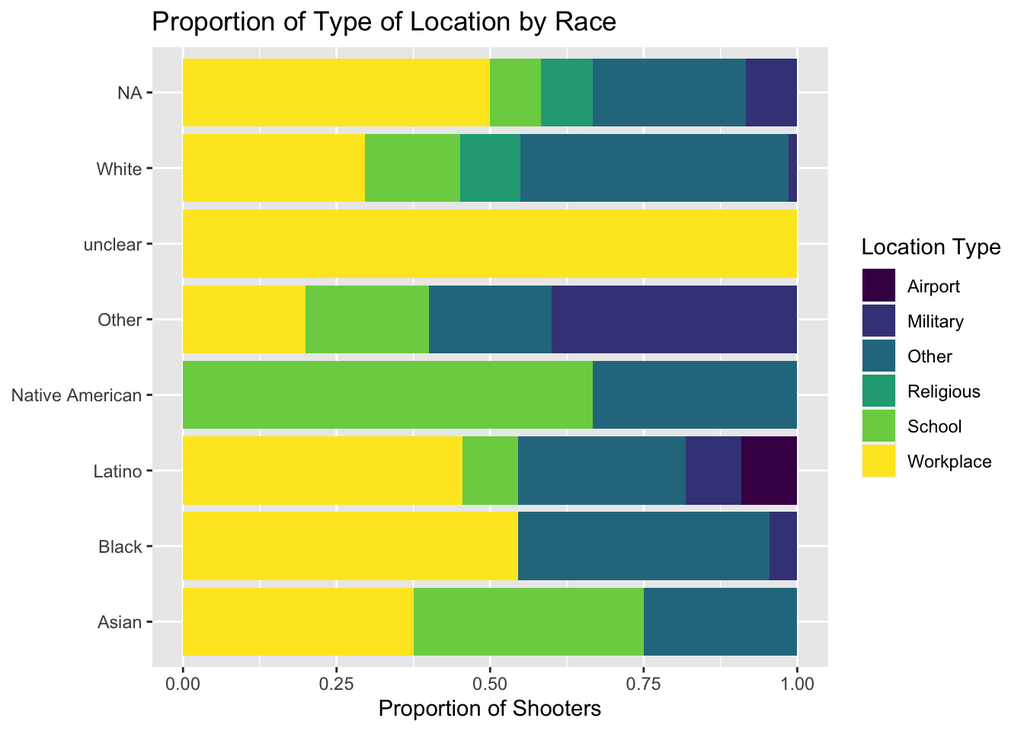

The proportion of school shootings is the highest for Native Americans.

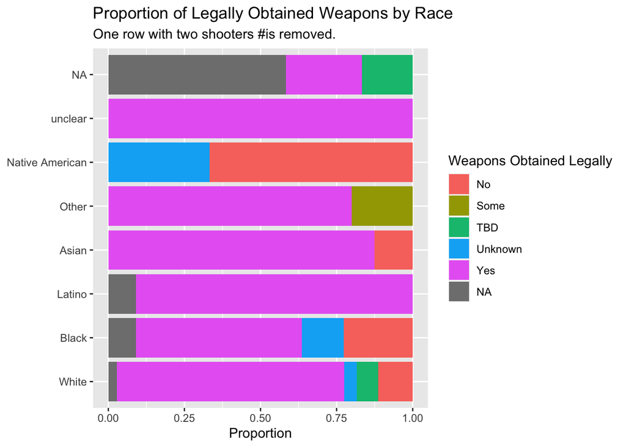

Native Americans have the highest proportion of illegally obtained weapons. Latinos have the highest probability of legally obtaining weapons.

Cleaned up the weapon_type variable:

```
## # A tibble: 71 × 2
##    weapon_type                                                                 n
##    <chr>                                                                   <int>
##  1 "2 assault rifles; semiautomatic handgun\r\n"                               1
##  2 "2 handguns"                                                                1
##  3 "23 firearms, mostly rifles; including scopes, and two modified for \"…     1
##  4 "9mm semi-automatic handgun"                                                1
##  5 "Assault rifle, high capacity magazines, antique handgun\r\n"               1
##  6 "Five pistols, one rifle, five magazines of ammunition"                     1
##  7 "handgun"                                                                   6
##  8 "Handgun"                                                                   2
##  9 "handgun\r\n"                                                               1
## 10 "handgun, shotgun"                                                          1
## # … with 61 more rows
```

```
## # A tibble: 67 × 2
##    weapon_type                                                          n
##    <chr>                                                            <int>
##  1 " revolver"                                                          1
##  2 " revolver,  shotgun"                                                2
##  3 " rifle"                                                             1
##  4 " rifle (assault)"                                                   4
##  5 " rifle,  revolver"                                                  1
##  6 " rifle,  revolver,  shotgun"                                        1
##  7 " rifle,  shotgun"                                                   1
##  8 " rifle, 2 shotguns"                                                 1
##  9 " semiautomatic handgun"                                            18
## 10 " semiautomatic handgun (assault),  rifle (assault), 2 shotguns"     1
## # … with 57 more rows
```

```
## # A tibble: 49 × 2
##    weapon_type_update                             n
##    <chr>                                      <int>
##  1 Semiautomatic handgun                         33
##  2 Semiautomatic rifle                           12
##  3 Handgun                                        9
##  4 Semiautomatic rifle, semiautomatic handgun     8
##  5 2 semiautomatic handguns                       6
##  6 <NA>                                           5
##  7 Rifle (assault)                                4
##  8 Semiautomatic handgun, revolver                4
##  9 Shotgun                                        4
## 10 2 handguns                                     3
## # … with 39 more rows
```

I took out the vest from one of the levels because it is not a weapon. I decided to remove the 9mm from the shotgun and .38 from revolver. I thought it was unnecessary as they are both specializations of these types of gun. A 9mm shotgun is the same as a shotgun. One is made before the other, so one is more specialized, kind of like a car model and make. I chose to remove ammunition magazines because they are simply storage for ammunition that is either inside or attached to a gun. All of the added unnecessary information had to be taken out because it causes the column to have too many levels because r thinks that a 9mm shotgun and a shotgun are different types of guns.

Looking at the count after all the wrangling, I can see that a single semiautomatic handgun was used the most in a mass shooting. This is not counting the times a semiautomatic gun was used along with another weapon.